# 9. Reporte avance académico

Asistente de investigación: Valentina Andrade

última actualización: 09 March,2023

# 1 Descripción del reporte

## 1.1 Variables dependientes

El siguiente reporte muestra un avance del análisis construido en base a los outcomes de avance académico que se definieron como equipo. Sea $i = \lbrace 1,2 \rbrace$ donde $i$ indica el año académico del estudiante, entonces definimos como

- `switch_{i}`: una variable que indica $1$ si el estudiante aparece en otra carrera que la de origen al año siguiente y $0$ si se mantiene. Se construye una medida para el sistema centralizado y para todo el sistema (con sufijo `\_all` )
- `enroll_{i}`: una variable que indica $1$ si el estudiante aparece matriculado al año siguiente y $0$ si no aparece matriculado al año siguiente, independiente de la carrera indicada. Se construye una medida para el sistema centralizado y para todo el sistema (con sufijo `\_all` )

Para el cálculo de las variables se consideró solo a los estudiantes que estuvieron matriculados en el año de ingreso original (ingreso inmediato).

## 1.2 Variables independientes

- `promlm`: promedio puntaje lenguaje y matemática en la prueba admisión
- `ptje_pref_sele`: puntaje ponderado en la carrera que fue seleccionado/a en la prueba de admisión

Ambas variables, cuando fueron agregadas, fueron calculadas como el promedio de la variable a nivel de carrera.

Las figuras presentadas son una selección. En la carpeta `04_analysis/figures/combine` podrán encontrar el resto de las figuras. A su vez, la estimación completa de los modelos está en `04_analysis/models`

## 1.3 Objetivo del reporte

El reporte busca analizar el efecto que tiene el desempeño académico (en las pruebas de admisión) sobre la retención (enroll) y el cambio de carrera (switch) de los estudiantes en el primer año, **según su forma de ingreso** (BEA, PACE o regular).

Evidentemente el resultado académico universitario (enroll o switch) depende de características de las carreras (por ejemplo, su dificultad). Es por ello que se controlan los análisis por efectos **efectos fijos** por carrera.

En síntesis, en análisis se basa en

1. Binscatter (gráfico de la derecha): corresponde a la relación bivariada entre el cuantil de desempeño académico en que el está la carrera, y la probabilidad de enroll/switch según la forma de ingreso del estudiante
2. Coefplots (gráfico de la izquierda): presenta los coeficientes estimados de un modelo con efecto fijo de carrera. En particular, la variable de interés en la interacción entre ser **elegible** a alguna **politica afirmativa** y el cuantil de de desempeño académico en la carrera que se matriculó por primera vez. Es decir, los coeficientes muestran la diferencia promedio en la probabilidad de estar retenido entre los elegibles PACE y regulares para cada uno de los cuantiles de performance académica de la carrera, controlando por el desempeño del estudiante y el efecto fijo de carrera. De manera simple, esto muestra el resultado académico en el primer año para un estudiante PACE y regular, según si la carrera es “más o menos competitiva/difícil” (según lo que se considere que mide el puntaje promedio ponderado).

Nota importante: notar coeficiente que está desordenado con un valor de quantil más bajo y aparece su efecto hacia otra dirección. Por problemas con el *reghdfe* se pone como categoría de referencia el 1 solo para una interacción.

## 1.4 enroll_1

Como se puede ver en la *Figura 1 y 2* la relación entre promedio de lenguaje matemática y puntaje ponderado sobre enroll no tiene la misma dirección de relación. Como se puede ver en *Figura 1* en promedio los PACE tienen menos probabilidad de *enroll* que un regular. Ahora bien, vemos que al **aumentar en el cuantil de puntaje ponderado**, los PACE van estrechando esa brecha con los regulares hasta **perder** su **significancia estadística** en los cuantiles superiores.

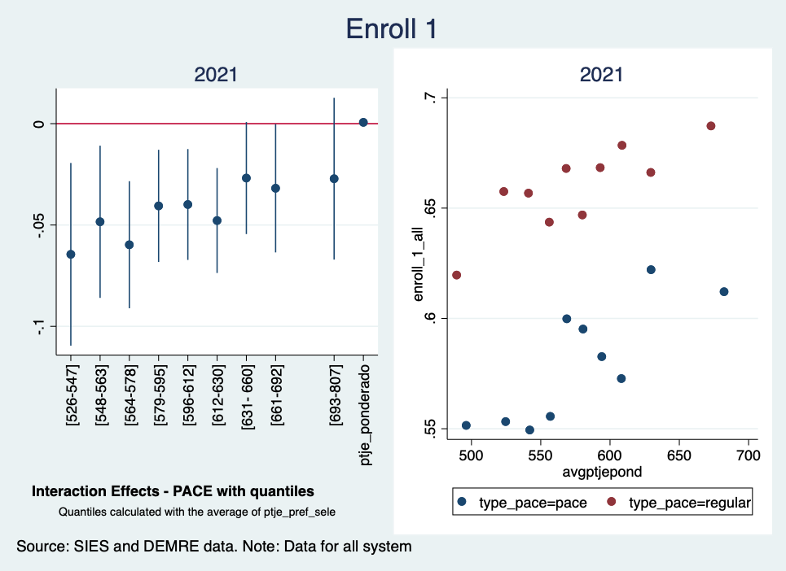

**Figura 1**. enroll_1 según puntaje ponderado (2021)

En la *Figura 2* el escenario es distinto: en carreras con menor puntaje en lenguaje y matemáticas los PACE hacen más enroll que los regulares. Pero desde el tercer cuantil en adelante la diferecia se invierte.

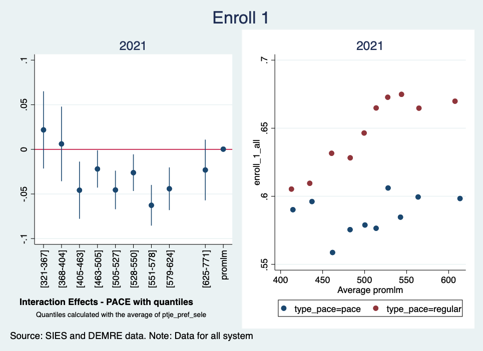

**Figura 2**. enroll_1 según puntaje promedio en matemáticas y lenguaje (2021)

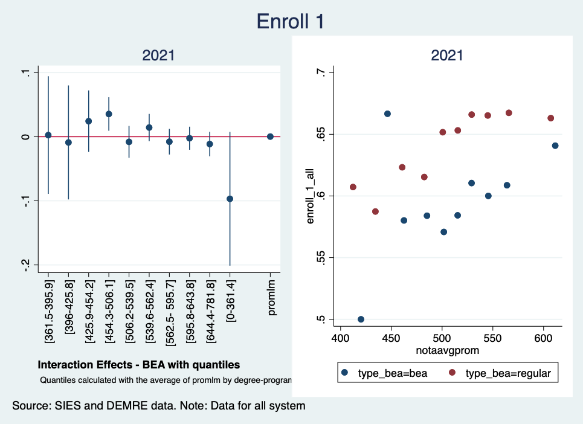

**Figura 3**. enroll_1 según puntaje promedio en matemáticas y lenguaje (2021)

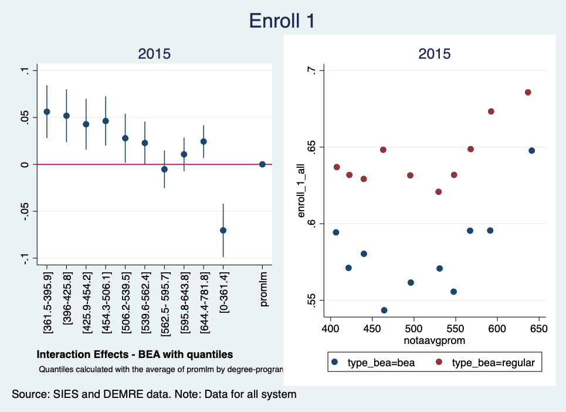

**Figura 4**. enroll_1 según puntaje promedio en matemáticas y lenguaje (2015)

## 1.5 enroll

En el caso de enroll a los 5 años de carrera el escenario es distinto, parece ser que los BEA tienen una menor persistencia que los regulares pese a que al primer año hacen más enroll (Figura 4). Lo que muestra la *Figura 5* es un hecho muy interesante: los BEA en promedio tienen menos probabilidad enroll a los 5 años que los regulares, pero esta **diferencia deja de ser estadísticamente significativa en cuantiles más altos**.

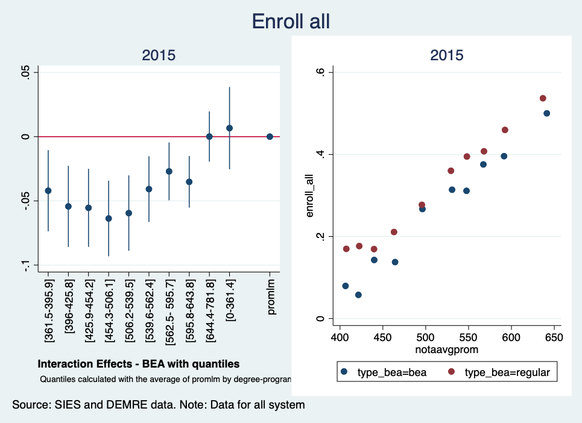

**Figura 5**. enroll según puntaje promedio en matemáticas y lenguaje (2015)

## 1.6 Switch

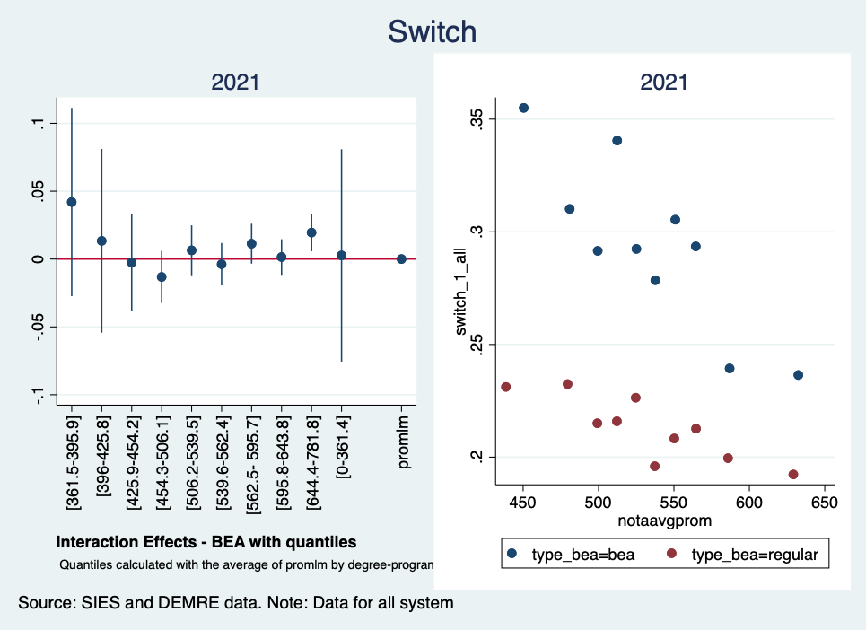

**Figura 6**. switch_1 según puntaje promedio en matemáticas y lenguaje (2021)